# Analysis of Education Inequality Using Python

## BY SHAHMEER ALI

### TOOLS USED IN THIS PROJECT PANDAS, NUMPY AND MATPLOTLIB

```python
import pandas as p

data = p.read_csv("inequality in Education.csv")
print(data.to_string())
```

```
    ISO3                               Country Human Development Groups UNDP Developing Regions  HDI Rank (2021)  Inequality in Education (2010)  Inequality in Education (2011)  Inequality in Education (2012)  Inequality in Education (2013)  Inequality in Education (2014)  Inequality in Education (2…
0    AFG                           Afghanistan                      Low                      SA            180.0                       42.809000                       44.823380                       44.823380                       44.823380                       44.823380                       45.36…
1    AGO                                Angola                   Medium                     SSA            148.0                             NaN                             NaN                             NaN                             NaN                             NaN                       34.17…
2    ALB                               Albania                     High                     ECA             67.0                       11.900000                       11.900000                       11.900000                       11.900000                       11.900000                       11.90…
3    AND                               Andorra                Very High                     NaN             40.0                       15.160302                       15.160302                       15.160302                       15.160302                        9.965681                       10.08…
4    ARE                  United Arab Emirates                Very High                      AS             26.0                             NaN                             NaN                             NaN                             NaN                             NaN                            …
5    ARG                             Argentina                Very High                     LAC             47.0                        6.914310                        6.830900                        6.430560                        6.513360                        6.192280                        6.33…
6    ARM                               Armenia                     High                     ECA             85.0                        3.685000                        3.685000                        3.685000                        3.685000                        3.685000                        3.68…
7    ATG                   Antigua and Barbuda                     High                     LAC             71.0                             NaN                             NaN                             NaN                             NaN                             NaN                            …
8    AUS                             Australia                Very High                     NaN              5.0                        2.746427                        2.477821                        2.475142                        2.935539                        2.832901                        2.72…
9    AUT                               Austria                Very High                     NaN             25.0                        2.488360                        3.667240                        3.489860                        4.297670                        2.658110                        2.60…
10   AZE                            Azerbaijan                     High                     ECA             91.0                        3.727167                        3.731171                        3.702155                        3.515670                        3.491246                        3.53…
11   BDI                               Burundi                      Low                     SSA            187.0                       40.970000                       40.970000                       36.868090                       36.868090                       36.868090                       36.86…
12   BEL                               Belgium                Very High                     NaN             13.0                        7.627000                        9.174500                        9.174500                        8.094880                        9.276420                        8.00…
13   BEN                                 Benin                      Low                     SSA            166.0                             NaN                       44.792260                       44.792260                       44.792260                       43.656390                       43.65…
```

[output cut: 181 more lines]

## firstly we loaded our full data now we will analyze the data

```python
data.info()
```

```
<class 'pandas.core.frame.DataFrame'>
RangeIndex: 195 entries, 0 to 194
Data columns (total 17 columns):
 #   Column                          Non-Null Count  Dtype
---  ------                          --------------  -----
 0   ISO3                            195 non-null    object
 1   Country                         195 non-null    object
 2   Human Development Groups        191 non-null    object
 3   UNDP Developing Regions         151 non-null    object
 4   HDI Rank (2021)                 191 non-null    float64
 5   Inequality in Education (2010)  137 non-null    float64
 6   Inequality in Education (2011)  150 non-null    float64
 7   Inequality in Education (2012)  157 non-null    float64
 8   Inequality in Education (2013)  165 non-null    float64
 9   Inequality in Education (2014)  168 non-null    float64
 10  Inequality in Education (2015)  168 non-null    float64
 11  Inequality in Education (2016)  168 non-null    float64
 12  Inequality in Education (2017)  168 non-null    float64
 13  Inequality in Education (2018)  172 non-null    float64
 14  Inequality in Education (2019)  174 non-null    float64
 15  Inequality in Education (2020)  176 non-null    float64
 16  Inequality in Education (2021)  176 non-null    float64
dtypes: float64(13), object(4)
memory usage: 26.0+ KB
```

### now we have all details of the data set now we will analyze its exact rows and columns

```python
print(data.shape)
print(data.columns)
```

```
(195, 17)
Index(['ISO3', 'Country', 'Human Development Groups',
       'UNDP Developing Regions', 'HDI Rank (2021)',
       'Inequality in Education (2010)', 'Inequality in Education (2011)',
       'Inequality in Education (2012)', 'Inequality in Education (2013)',
       'Inequality in Education (2014)', 'Inequality in Education (2015)',
       'Inequality in Education (2016)', 'Inequality in Education (2017)',
       'Inequality in Education (2018)', 'Inequality in Education (2019)',
       'Inequality in Education (2020)', 'Inequality in Education (2021)'],
      dtype='object')
```

```python
head_data =  data.head(10)
new_data = head_data.dropna(inplace=True)
print(head_data.to_string())
```

```
  ISO3      Country Human Development Groups UNDP Developing Regions  HDI Rank (2021)  Inequality in Education (2010)  Inequality in Education (2011)  Inequality in Education (2012)  Inequality in Education (2013)  Inequality in Education (2014)  Inequality in Education (2015)  Inequality in Educati…
0  AFG  Afghanistan                      Low                      SA            180.0                        42.80900                        44.82338                        44.82338                        44.82338                        44.82338                        45.36517                       …
2  ALB      Albania                     High                     ECA             67.0                        11.90000                        11.90000                        11.90000                        11.90000                        11.90000                        11.90000                       …
5  ARG    Argentina                Very High                     LAC             47.0                         6.91431                         6.83090                         6.43056                         6.51336                         6.19228                         6.33131                       …
6  ARM      Armenia                     High                     ECA             85.0                         3.68500                         3.68500                         3.68500                         3.68500                         3.68500                         3.68500                       …
```

[output not shown]

All empty cell are removed from the dataset

```python
data.dropna(inplace=True)
print(data.duplicated())
print(data.to_string())
```

```
0      False
2      False
5      False
6      False
10     False
       ...
187    False
188    False
191    False
193    False
194    False
Length: 91, dtype: bool
    ISO3                               Country Human Development Groups UNDP Developing Regions  HDI Rank (2021)  Inequality in Education (2010)  Inequality in Education (2011)  Inequality in Education (2012)  Inequality in Education (2013)  Inequality in Education (2014)  Inequality in Education (2…
0    AFG                           Afghanistan                      Low                      SA            180.0                       42.809000                       44.823380                       44.823380                       44.823380                       44.823380                       45.36…
2    ALB                               Albania                     High                     ECA             67.0                       11.900000                       11.900000                       11.900000                       11.900000                       11.900000                       11.90…
```

[output cut: 89 more lines]

```python
maximum = data["Inequality in Education (2010)"].max()
# data[data["Inequality in Education (2021)"] == maximum]
filt  = data.filter(like="Inequality in Education")
print(filt.max().to_string())
```

```
Inequality in Education (2010)    48.72300
Inequality in Education (2011)    48.72300
Inequality in Education (2012)    48.72300
Inequality in Education (2013)    48.26536
Inequality in Education (2014)    48.26536
Inequality in Education (2015)    48.26536
Inequality in Education (2016)    48.26536
Inequality in Education (2017)    48.26536
Inequality in Education (2018)    50.12411
Inequality in Education (2019)    50.12411
Inequality in Education (2020)    50.12411
Inequality in Education (2021)    50.12411
```

the maximum inequality in eduction from 2010-2021

```python
for col in filt.columns:
    maximum = data[col].max()
    country = data.loc[data[col] == maximum ,"Country"].values
    years = col[-5:-1]

    for country in country:
        print(f"the maximum inequality in Education in {country} in year: {years} is {maximum} " )
```

```
the maximum inequality in Education in Sierra Leone in year: 2010 is 48.723
the maximum inequality in Education in Sierra Leone in year: 2011 is 48.723
the maximum inequality in Education in Sierra Leone in year: 2012 is 48.723
the maximum inequality in Education in Guinea in year: 2013 is 48.26536
the maximum inequality in Education in Guinea in year: 2014 is 48.26536
the maximum inequality in Education in Guinea in year: 2015 is 48.26536
the maximum inequality in Education in Guinea in year: 2016 is 48.26536
the maximum inequality in Education in Guinea in year: 2017 is 48.26536
the maximum inequality in Education in Guinea in year: 2018 is 50.12411
the maximum inequality in Education in Guinea in year: 2019 is 50.12411
the maximum inequality in Education in Guinea in year: 2020 is 50.12411
the maximum inequality in Education in Guinea in year: 2021 is 50.12411
```

so we have the maximum inequality in education from year 2010 to 2021

```python
for col in filt.columns:
    minimun = data[col].min()
    country = data.loc[data[col] == minimun , "Country"].values
    years = col[-5:-1]

    for country in country:
        print(f"the minimum inequality in Education in {country} in year: {years} is {minimun}")
```

```
the minimum inequality in Education in Moldova in year: 2010 is 3.573789055
the minimum inequality in Education in Moldova in year: 2011 is 3.487020812
the minimum inequality in Education in Moldova in year: 2012 is 3.254724925
the minimum inequality in Education in Moldova in year: 2013 is 3.247362894
the minimum inequality in Education in Moldova in year: 2014 is 2.925775997
the minimum inequality in Education in Moldova in year: 2015 is 2.759083599
the minimum inequality in Education in Moldova in year: 2016 is 2.759083599
the minimum inequality in Education in Moldova in year: 2017 is 2.759083599
the minimum inequality in Education in Moldova in year: 2018 is 2.570094084
the minimum inequality in Education in Moldova in year: 2019 is 2.570094084
the minimum inequality in Education in Moldova in year: 2020 is 2.570094084
the minimum inequality in Education in Moldova in year: 2021 is 2.570094084
```

NOW WE HAVE THE MINIMUM IEQUALITY IN EDUCATION FROM 2010-2021

```python
data["average inequality by country"] = filt.mean(axis=1,skipna=True)
print(filt.mean(axis=1))

print(data[["Country","average inequality by country"]].to_string())
```

```
0      44.971559
2      12.080600
5       6.240564
6       3.309975
10      3.589988
         ...
187    11.439762
188    16.888245
191    46.625768
193    21.976877
194    16.644445
Length: 91, dtype: float64
                                  Country  average inequality by country
0                             Afghanistan                      44.971559
2                                 Albania                      12.080600
```

[output cut: 89 more lines]

THIS IS THE AVERAGE OF THE INEQUALITY IN EDUCATION COUNTRY WISE

```python
average_by_year = filt.mean()
print(average_by_year)
```

```
Inequality in Education (2010)    25.932120
Inequality in Education (2011)    25.609196
Inequality in Education (2012)    25.355953
Inequality in Education (2013)    25.040761
Inequality in Education (2014)    24.940542
Inequality in Education (2015)    24.607302
Inequality in Education (2016)    24.206738
Inequality in Education (2017)    24.058842
Inequality in Education (2018)    23.798169
Inequality in Education (2019)    23.754369
Inequality in Education (2020)    23.726671
Inequality in Education (2021)    23.726671
dtype: float64
```

THIS IS THE AVERAGE OF THE INEQUALITY IN EDUCATION YEAR WISE

```python
starting_year = average_by_year.iloc[0]
last_year = average_by_year.iloc[-1]
print(f"the average of the 2010 is ({starting_year}) \nthe average of the 2021 is ({last_year})")

if last_year < starting_year:
    print(f"THE INEQUALITY IN EDUCTION IS DECREASED OVER YEARS ")
else:
    print(f"THE INEQUALITY IN EDUCATION IS INCREASED OVER YEARS")
```

```
the average of the 2010 is (25.932120017549444)
the average of the 2021 is (23.726670933483522)
THE INEQUALITY IN EDUCTION IS DECREASED OVER YEARS
```

```python
import numpy as n

x = n.array(filt)

print(f"converting all the inequality in education data in to array \n{x}")
mean = n.mean(filt)

print(f"average of all the inequality in education data : {mean}")
median = n.median(filt)
print(f"middle sorted value  of all the inequality in education data : {median}")

print("all the details of all the inequality in education data \n",filt.describe().to_string())
deviation = n.std(filt)
print(f"standard value of all the inequality in education data \n{deviation}")
print(f"minimum value from the all the inequality in education data is {n.min(filt)}")
print(f"maximum value from the all the inequality in education data is {n.max(filt)}")
print("Detecting outlier values")
```

```
converting all the inequality in education data in to array
[[42.809   44.82338 44.82338 ... 45.36517 45.36517 45.36517]
 [11.9     11.9     11.9     ... 12.33344 12.33344 12.33344]
 [ 6.91431  6.8309   6.43056 ...  5.78729  5.78729  5.78729]
 ...
 [48.09012 48.09012 48.09012 ... 46.13765 46.13765 46.13765]
 [23.76    23.76    23.76    ... 20.43572 20.43572 20.43572]
 [17.825   17.825   17.825   ... 14.60503 14.60503 14.60503]]
average of all the inequality in education data : 24.563111179177657
middle sorted value  of all the inequality in education data : 22.62432086
all the details of all the inequality in education data
        Inequality in Education (2010)  Inequality in Education (2011)  Inequality in Education (2012)  Inequality in Education (2013)  Inequality in Education (2014)  Inequality in Education (2015)  Inequality in Education (2016)  Inequality in Education (2017)  Inequality in Education (2018)  Ineq…
count                       91.000000                       91.000000                       91.000000                       91.000000                       91.000000                       91.000000                       91.000000                       91.000000                       91.000000       …
mean                        25.932120                       25.609196                       25.355953                       25.040761                       24.940542                       24.607302                       24.206738                       24.058842                       23.798169       …
std                         12.830450                       12.920716                       13.179696                       13.143109                       13.292222                       13.468494                       13.490831                       13.550860                       13.726471       …
min                          3.573789                        3.487021                        3.254725                        3.247363                        2.925776                        2.759084                        2.759084                        2.759084                        2.570094       …
25%                         17.015997                       15.420023                       15.043697                       13.935858                       13.526302                       13.309752                       12.123356                       12.107951                       12.006201       …
50%                         24.470251                       24.470251                       23.760000                       23.760000                       22.895520                       22.154491                       22.464432                       21.940165                       22.108177       …
75%                         39.476275                       38.716385                       37.505545                       37.505545                       37.125730                       37.125730                       36.905500                       37.322660                       37.139840       …
max                         48.723000                       48.723000                       48.723000                       48.265360                       48.265360                       48.265360                       48.265360                       48.265360                       50.124110       …
standard value of all the inequality in education data
Inequality in Education (2010)    12.759758
Inequality in Education (2011)    12.849527
Inequality in Education (2012)    13.107081
Inequality in Education (2013)    13.070694
Inequality in Education (2014)    13.218986
Inequality in Education (2015)    13.394287
Inequality in Education (2016)    13.416501
Inequality in Education (2017)    13.476199
Inequality in Education (2018)    13.650843
Inequality in Education (2019)    13.724517
Inequality in Education (2020)    13.769364
Inequality in Education (2021)    13.769364
dtype: float64
minimum value from the all the inequality in education data is 2.570094084
maximum value from the all the inequality in education data is 50.12411
Detecting outlier values
```

[output not shown]

```python
print(n.isnan(filt).sum())
z_score = (filt - mean) / deviation
outliers = filt.where(n.abs(z_score) > 3).any()


outliers
```

```
Inequality in Education (2010)    0
Inequality in Education (2011)    0
Inequality in Education (2012)    0
Inequality in Education (2013)    0
Inequality in Education (2014)    0
Inequality in Education (2015)    0
Inequality in Education (2016)    0
Inequality in Education (2017)    0
Inequality in Education (2018)    0
Inequality in Education (2019)    0
Inequality in Education (2020)    0
Inequality in Education (2021)    0
dtype: int64
```

```
Inequality in Education (2010)    False
Inequality in Education (2011)    False
Inequality in Education (2012)    False
Inequality in Education (2013)    False
Inequality in Education (2014)    False
Inequality in Education (2015)    False
Inequality in Education (2016)    False
Inequality in Education (2017)    False
Inequality in Education (2018)    False
Inequality in Education (2019)    False
Inequality in Education (2020)    False
Inequality in Education (2021)    False
dtype: bool
```

Z-score analysis showed that no values exceeded the threshold of |Z| > 3. This indicates the absence of extreme outliers in the inequality dataset.

```
[25.93212002 25.60919593 25.35595306 25.04076112 24.94054244 24.60730236
 24.20673791 24.05884176 23.79816907 23.75436863 23.72667093 23.72667093]
['2010' '2011' '2012' '2013' '2014' '2015' '2016' '2017' '2018' '2019'
 '2020' '2021']
```

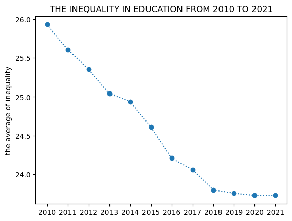

```python
import matplotlib.pyplot as mp
x = n.array(average_by_year)
print(x)
filt_copy = filt.copy()
filt_copy.columns = filt_copy.columns.str.extract(r'(\d{4})')[0]
hello2 = filt.columns
y = n.array(filt_copy.columns)
print(y)
mp.title("THE INEQUALITY IN EDUCATION FROM 2010 TO 2021")
mp.ylabel("the average of inequality")
mp.plot(y,x,marker = "o" ,linestyle = ":")
```

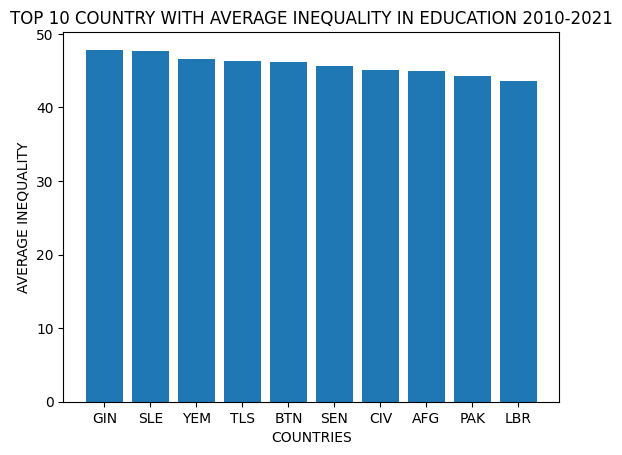

```python
data["avg_ineq_c"] = filt.mean(axis=1)
top10 = data[["ISO3","avg_ineq_c"]].sort_values(by="avg_ineq_c",ascending=False).head(10)
c  = n.array(top10["ISO3"])
avg = n.array(top10["avg_ineq_c"])
mp.bar(c,avg)
mp.title("TOP 10 COUNTRY WITH AVERAGE INEQUALITY IN EDUCATION 2010-2021")
mp.xlabel("COUNTRIES")
mp.ylabel("AVERAGE INEQUALITY")
```